# Encoding Categorical Predictors

3/24/2020

## 5. Categorical Predictors

- qualitative meaning
- ordered or unordered
- exception models
  - tree based
  - naive Bayes model

## 5.1 Creating Dummy Variables for Unordered

- contrast / parameterization function
  - reference cell / treatment
- C level C-1 dummy variables
  - full rank parameterization
  - insensitive model (glmnet)
- interpretation of the dummy variables
  - intercept value estimates the mean of the reference cell
  - dummy variable estimates
  - multidimensional reference cell
  - cell means parameterization no intercept

## 5.2 Encoding Predictors with many categories

- C categories, and C is big
  - rare occurrence, zero-variance
- solutions
  - remove zero variance dummy variables
  - resampling
  - have nero-zero variance ratio cutoff
  - set an ‘other’ category
  - hashing function

## 5.3 Approaches for novel categories

- not seen category
  - set an ‘other’ category

## 5.4 Supervised Encoding Methods

- encoding categorical predictors using the outcome as guide
  - effect of likelihood encoding
    - regression problem, using mean / median output to represent the factor level
    - classification problem, logistic regression models the log-odds of the outcome as a function of the predictiors
    - shrinkage method using Bayesian analysis: a posterior distribution
  - deep learning: word embedding

## 5.5 Encodings for Ordered Data

- information contained in the relative ordering
  - polynomial contrast
    - may not effectively relate a predictor to the response
    - can’t scale up
  - treat as unordered
  - translate the ordered into a single set of numeric scores

## 5.6 Creating Features from text data

- indicator of a hyperlink: test for difference in proportions example
- features: number of commas, hashtags,mentions, exclamation points
- odds-ratios of occurrences of words, and p-value
  - can’t answer how much of difference is there between the groups
  - when there are hundreds of tests on the same data set, raises the false positive rate exponentially

## 5.6 Creating Features from text data

- removing commonly used stop words
- stemming the words so that similar words are represented as a single entity
- tf-idf
  - the same raw count is down-weighted according to its abundance in the overall data set
- n-grams

## 5.7 Factors versus Dummy Variables in Tree based models

- does it matter how the predictions are encoded?
  - the percent difference in performance

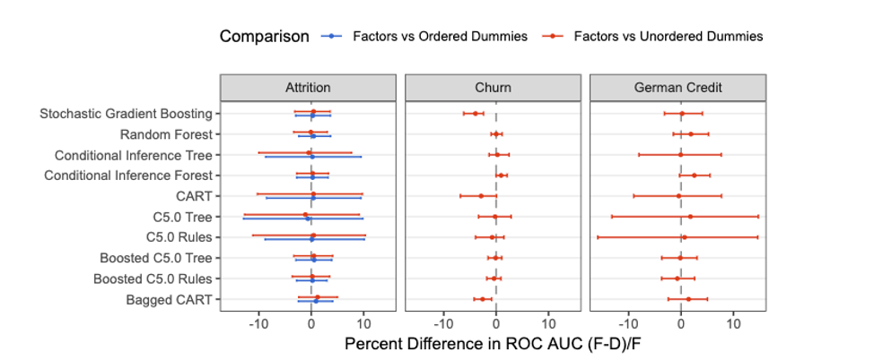

## 5.7 Factors versus Dummy Variables in Tree based models

- does it matter how the predictions are encoded?
  - overall accuracy

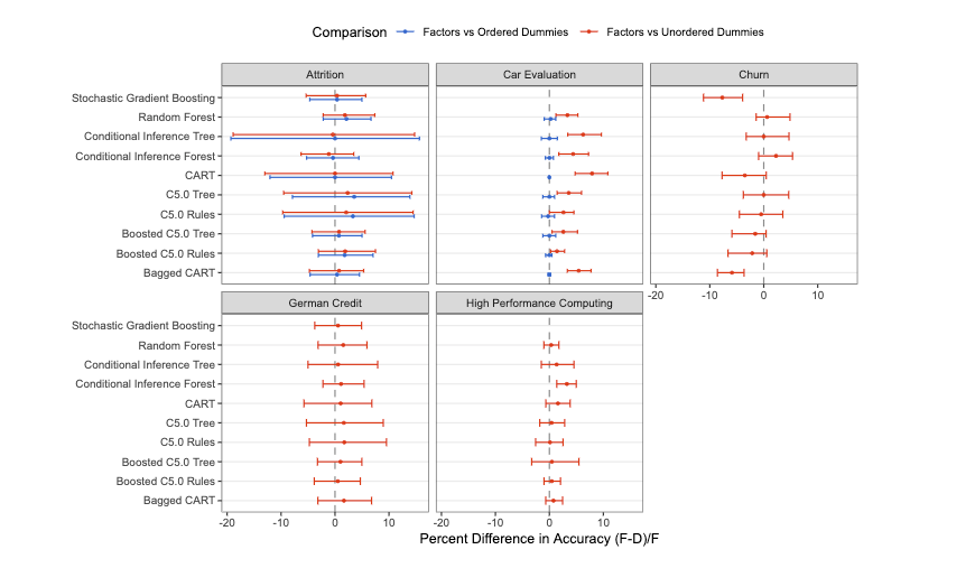

## 5.7 Factors versus Dummy Variables in Tree based models

- does it matter how the predictions are encoded?
  - the time to train the models

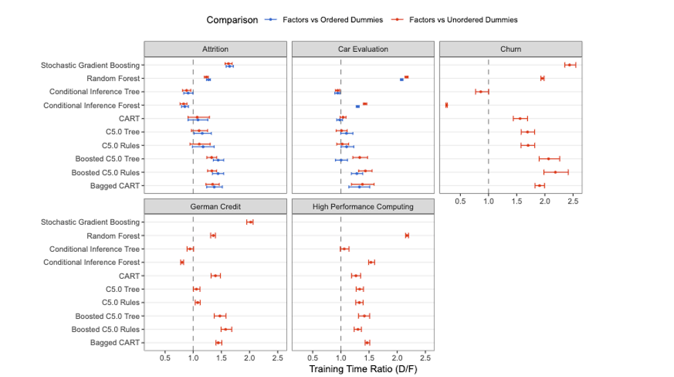

## 5.7 Factors versus Dummy Variables in Tree based models

- suggest using the predictors without converting to dummy variables
- if the model appears promising, to also try refitting using dummy variables